# NCAA Basketball Analysis

4/23/24

## Outline

In this lecture, we will…

- Introduce our what our data contains and interesting findings
- Discuss Multiple Linear Regression
- Discuss Regression Tree
- Discuss Polynomial Regression
- Compare findings

## Our Data

## Columns

- This data contained 24 different columns of data from team name, games played and won, two point and three point shooting percentages for themselves and for their match up. There was only four categorical variables: Team name, Conference, Seed and Postseason result which was where they got knocked out.
- Our most important variables were BARTHAG (Power Rating), Win percentage, Power 5, Number of games played and Number of games won.
  - Win Percentage (win_perc) and Power 5 (power_5) were created variables by us in order to achieve our goal

## Our Response Variable…

- Our response variable was Win Percentage as the number of games played differed from team to team
  - Win Percentage was found by simply dividing the number of games won by the total number of games played
- Our main goal is to determine how the power rating of a team effects its win percentage across various seasons. Then to determining what model is best for predicting this percentage.
- Our data was also divided by Power 5 which determined whether a team was in a power five conference which are the biggest and most competitive conferences in the nation

## Linear Regression

## Finding relative variables

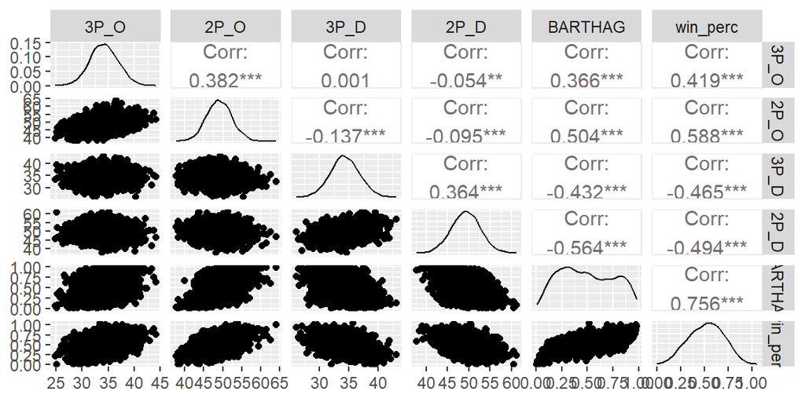

- - Our variable with the most correlation to our response variable was BARTHAG
    - BARTHAG is a teams power rating, in other words, the chance of beating an average D1 team

## Simple Linear Regression

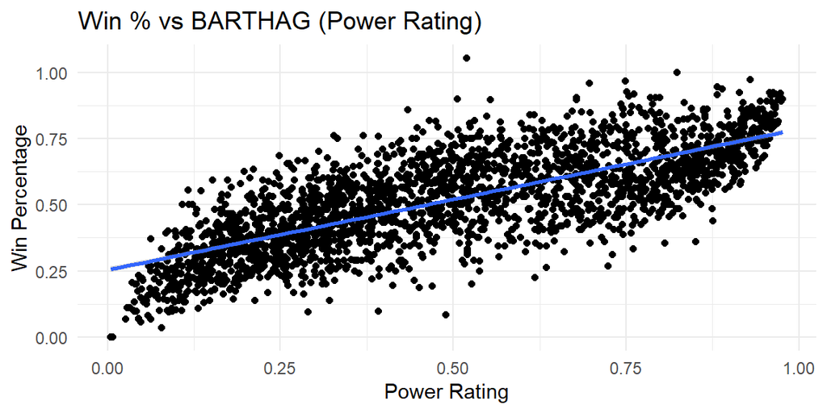

The relationship is decently significant and compared to the rest of our variable it does correlate the most as the more a teams power rating increases, their win percentage does tend to increase as well but not by a significant amount

## Multiple Linear Regression

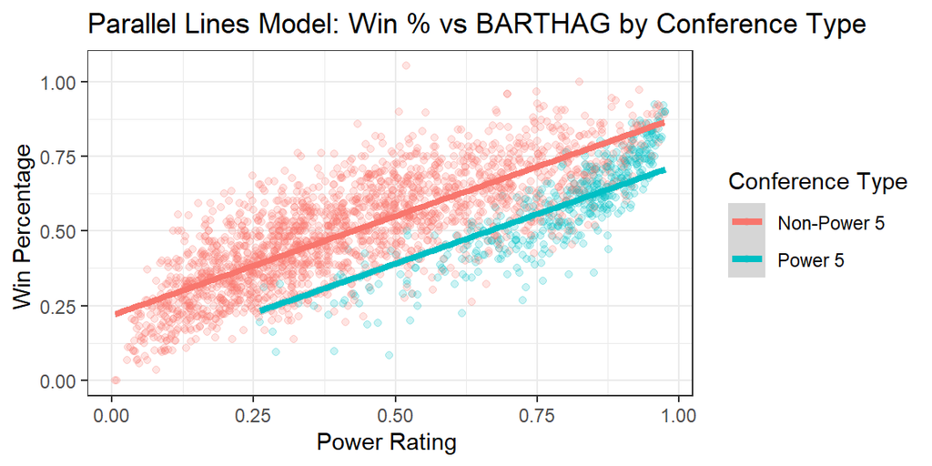

Teams in a power five conference had a higher average power rating compared to teams not in a power five conference. However, the more teams in a power conference had a lower win percentage, most likely due to being in a more competitive conference overall.

The RMSE for this model is 0.1088913

## Regression Tree

## The Best Tree

- RMSE measures how well the regression tree predicts win percentage.
- As cp increases, RMSE also increases, indicating that pruning the tree too much reduces predictive accuracy.
- This helps us tune our regression tree by choosing the best cp value that minimizes RMSE

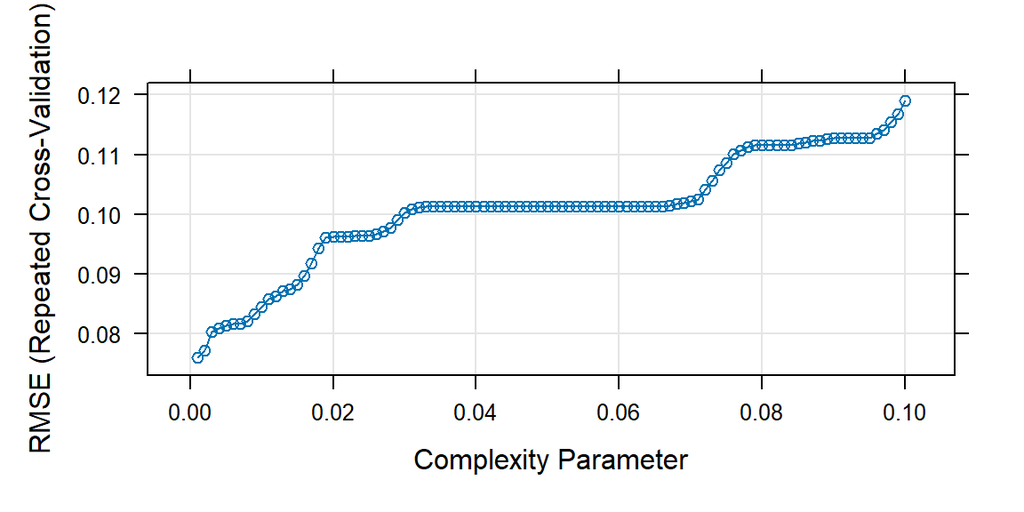

## The Best Tree

- Each split represents a decision rule that helps predict win percentage based on different variables.
- The deeper the tree, the more splits, which means more predictions.
- The tree confirms that WAB and BARTHAG are crucial for predicting win percentage, aligning with our expectations.

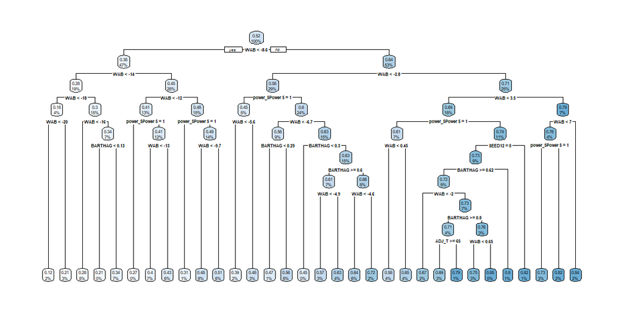

## LM

```
##
## Call:
## lm(formula = .outcome ~ ., data = dat)
##
## Residuals:
##      Min       1Q   Median       3Q      Max
## -0.53199 -0.04152  0.00514  0.04703  0.31691
##
## Coefficients:
##                    Estimate Std. Error t value Pr(>|t|)
## (Intercept)       0.7037543  0.0377351  18.650  < 2e-16 ***
## BARTHAG          -0.1274266  0.0168750  -7.551 6.05e-14 ***
## `power_5Power 5` -0.1326741  0.0046798 -28.350  < 2e-16 ***
## ADJ_T             0.0009527  0.0004756   2.003 0.045272 *
## SEED10            0.0250077  0.0198155   1.262 0.207060
## SEED11            0.0623505  0.0188070   3.315 0.000929 ***
## SEED12            0.1281693  0.0194366   6.594 5.22e-11 ***
## SEED13            0.1314902  0.0195872   6.713 2.36e-11 ***
## SEED14            0.1341313  0.0199206   6.733 2.06e-11 ***
## SEED15            0.1527132  0.0202869   7.528 7.22e-14 ***
## SEED16            0.1604478  0.0192328   8.342  < 2e-16 ***
## SEED2             0.0223955  0.0194777   1.150 0.250337
## SEED3             0.0312407  0.0189231   1.651 0.098881 .
## SEED4             0.0337978  0.0197493   1.711 0.087145 .
## SEED5             0.0361993  0.0191785   1.887 0.059213 .
## SEED6             0.0161131  0.0198667   0.811 0.417410
## SEED7             0.0557784  0.0188416   2.960 0.003102 **
## SEED8             0.0396877  0.0199555   1.989 0.046834 *
## SEED9             0.0172438  0.0194948   0.885 0.376495
## `SEEDN/A`         0.0865784  0.0153759   5.631 2.00e-08 ***
## WAB               0.0325739  0.0006616  49.235  < 2e-16 ***
## ---
## Signif. codes:  0 '***' 0.001 '**' 0.01 '*' 0.05 '.' 0.1 ' ' 1
##
## Residual standard error: 0.07206 on 2445 degrees of freedom
## Multiple R-squared:  0.8429, Adjusted R-squared:  0.8416
## F-statistic: 655.9 on 20 and 2445 DF,  p-value: < 2.2e-16
```

## Comparing The Models

- Intercept Model Performs Better

```
##   intercept       RMSE  Rsquared        MAE     RMSESD RsquaredSD       MAESD
## 1      TRUE 0.07227086 0.8409299 0.05544106 0.00327195 0.01486667 0.001754867
```

## Comparing The Models

- CP Model is Worse in Every Metric

```
##      cp       RMSE  Rsquared        MAE      RMSESD RsquaredSD      MAESD
## 1 0.001 0.07579249 0.8251942 0.05803881 0.004878744 0.02358809 0.00314813
```

## Polynomial Regression

## Which degree should we use?

- To figure out which degree polynomial to use, we calculated RMSE for each degree
- 3rd degree seems to be the best suitable, after that the RMSE doesn’t change much

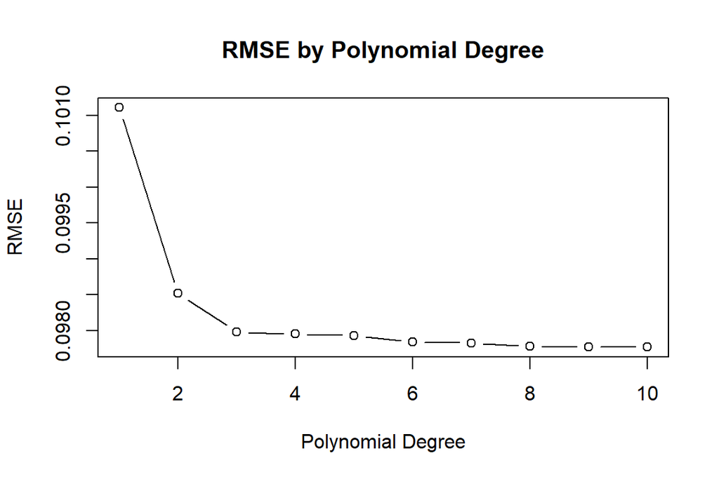

## Visualizing the Polynomial Regression

[figure not shown]

- Power 5 teams on average have a much higher power rating than Non-Power 5 teams, even with win percentage being relatively close between the two